# Bilan de Démarrage du Projet PAT

# 7 exemples sur R (lignes ) et contre exemples

On voulait réaliser un graphique de la distribution des PAT selon leur dernière étape d’avancement réalisée, en fonction de leur niveau, afin de voir à quelles étapes se situent les PAT de niveau 1 et de niveau 2.

```r
n_et_e<- as.data.frame(cbind(niveau = pat2025$niveaux_de_labelisation,
                             steps = pat2025$les_etapes_cles_conduites_et_realisees ))

summary(n_et_e)
```

```
##     niveau             steps
##  Length:462         Length:462
##  Class :character   Class :character
##  Mode  :character   Mode  :character
```

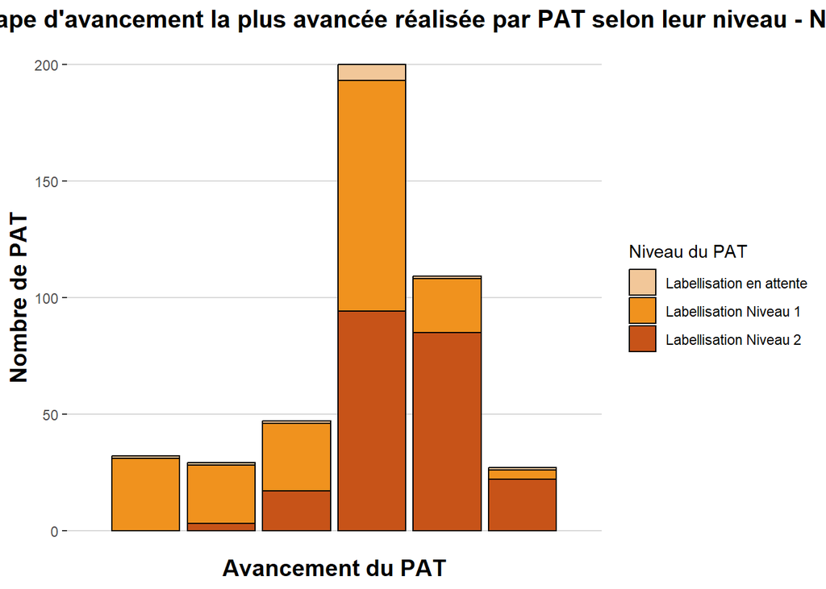

```r
  trans_etapes <- function(etapes){

  for (j in 1:length(etapes)){
    if (is.na(etapes[j])) {
      etapes[j] <- ""
      next
    }

    virg <- str_count(string = etapes[j], pattern = ",") # compte le nombre de virgules => virg + 1 = nombre d'étapes
    etapes[j] <- str_split_i(string = etapes[j], pattern= ", ", i = virg+1) # couper un espace après la virgule et garder le dernier élément (de num virg + 1)
    # conserve la dernière étape

    if (etapes[j]=="plans d'actions établis par délibération"){
     etapes[j]<- "Trois ou plus, plans d'actions établis par délibération"
    }
  }
  # Transformation en nombre
  etapes <- case_when(
    etapes == "Concertation" ~ 1,
         etapes == "Stratégie du projet construite et validée" ~ 2,
         etapes == "Premier plan d'action établi par une délibération" ~ 3,
         etapes == "Mise en oeuvre du premier plan d'action" ~ 4,
         etapes == "Second plan d'action établi par une délibération" ~ 5,
         etapes == "Trois ou plus, plans d'actions établis par délibération" ~ 6,
         etapes == "" ~ NA
  )
  return(etapes)
}

n_et_e$steps <- trans_etapes(n_et_e$steps)
n_et_e$niveau[is.na(n_et_e$niveau)] <- "NA"


n_et_e %>% ggplot() +
  aes(x = steps, group = niveau, fill = niveau) +
  geom_bar(col="black") +
  scale_fill_manual(values = c("#F2C799","#F0921E","#C75318","grey")) +
  labs(fill = "Niveau du PAT")+
  ylab("Nombre de PAT") +
  xlab("Avancement du PAT") +
  scale_x_discrete(labels = c(
    "Concertation",
    "Stratégie construite",
    "Premier plan d'action établi",
    "Mise en oeuvre 1er plan",
    "Second plan d'action établi","≥3 plans établis"
  ))+
  ggtitle(label = "Etape d'avancement la plus avancée réalisée par PAT selon leur niveau - Novembre 2025")+
  theme(panel.background = element_rect(fill="white"),
        plot.title = element_text(face="bold",hjust=0.2,size=15),
        axis.title.x = element_text(size=14,face="bold"),
        axis.title.y = element_text(size=14,face="bold"),
        panel.grid.major = element_line(colour = "grey85"),
        axis.ticks.x = element_blank(),
        axis.text.x = element_text(vjust=0.65,angle=50,size=12,colour="black"))
```

# 8 Quelles sont les variables les plus importantes ? Pourquoi chaque variable a -t-elle été enregistrée ?

On a cherché à comprendre au sein du fichier de description des PAT, pourquoi chacune des variables a été demandée dans le questionnaire

On a : - étudié les taux de NA pour chaque variable - cherché à comprendre quelles variables pourraient être sélectionnées comme variables illustratives pour qualifier nos PAT - chercher à comprendre quelle dimension de variabilité se cache derrière chacune de ces variables sélectionnées.

La liste des variables du fichier “description” se trouve dans le fichier “modele de données” dans la base France PAT. Ce fichier n’est pas à jour, les variables ayant évolué depuis 2024.

Voici les variables qui manquaient : Nombre de communes du territoires Sau en hectare Pourcentage_de_la_surface_des_prairies_permanentes Pourcentage_de_la_surface_des_cultures_de_legumineuses metres_de_haie_par_hectare_de_sau Microgrammes_de_produits_phytopharmaceutiques_par_litre_deau Milligrammes_de_nitrates_par_litre_deau M3_deau_utilise_pour_lirragation Evolution_de_lirrigation_depuis_5_ans Metres_de_haie_par_hectare_de_sau Nombre_denseignes_de_distribution Nombre_denseignes_de_distribution_de_gms Nombre_demplois_dans_la_transformation nombre_de_cantines_inscrites Evolution_du_nombre_demplois_dans_la_transformation_entre_2018_et_2023 Nombre_de_restaurants_collectifs_sur_le_territoire_qui_ont_fait_leur_teledeclaration_sur_ma_cantine nombre_dassociations_luttant_contre_la_precarite_alimentaire nombre_dassociations_luttant_contre_la_precarite_alimentaire_par_10km2 nombre_dassociations_luttant_contre_la_precarite_alimentaire_par_1000habitants

Taux de NA

```r
library(VIM)
```

```r
NA_graph <- aggr(x=pat2025,numbers=T,sortVar=F, plot= F)
res.na <- NA_graph$count
```

[figure not shown]

# 9 Description des PAT

La colonne “description_libre_des_enjeux_par_le_porteur” est une variable très intéressante, dans laquelle le porteur de projet résume les enjeux de ce projet alimentaire pour son territoire. Cette donnée textuelle caractérise donc les PAT. Elle porte un facteur de variabilité individuelle puisque les PAT sont décrits par leur porteur de projet.

Cette donnée sera mise en lien avec d’autres données textuelles, notamment les variables “objectifs_strategiques” afin de comprendre en quelles proportions les enjeux développés sont traduits ensuites en objectifs dans le PAT.

On s’est demandés combien de PAT n’avaient pas de description. On s’est ensuite demandés combien de PAT n’avaient pas de description selon leur niveau de labellisation.

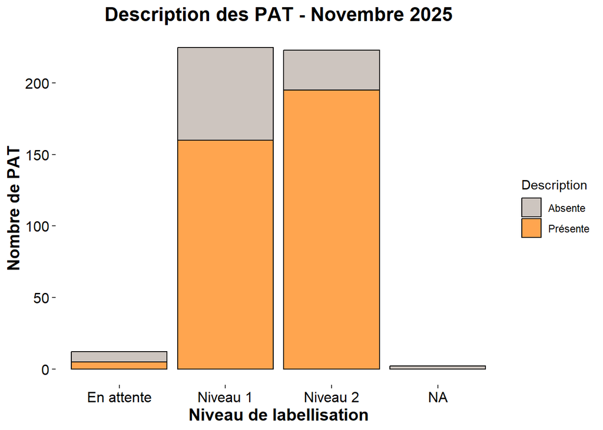

```r
pat2025$description_presente <- ifelse(is.na(pat2025$descriptions_libre_des_enjeux_du_territoire_par_le_porteur),"Absente","Présente")

pat2025 %>%
  ggplot() +
  geom_bar(aes(x=niveaux_de_labelisation,fill=description_presente,),
           color="black",position = "stack") +
  xlab("Niveau de labellisation") +
  ylab("Nombre de PAT")+
  ggtitle(label = "Description des PAT - Novembre 2025")+
  scale_x_discrete(labels = c("En attente","Niveau 1","Niveau 2","NA"))+
  scale_fill_discrete(name = "Description",palette = c("seashell3","tan1"))+
  theme(axis.text.x = element_text(size=12,colour = "black"),
        axis.text.y = element_text(size=12,colour = "black"),
        axis.title.x =  element_text(size=14,face="bold"),
        axis.title.y =  element_text(size=14,face="bold"),
        panel.background = element_rect(fill="white"),
        plot.title = element_text(size=16,face="bold",hjust=0.5))
```

Il y a t-il un lien entre les ‘descriptions_des_enjeux_par_le_porteur’ et les ‘objectifs_strategiques’ ? Peut-on associer ces descriptions aux objectifs en faisant du matching de texte ? (correspondance entre enjeux et obj en %)

# 10 Objectif stratégiques des PAT

Est-il intéressant de garder les 5 colonnes de ‘objectifs_strategiques’ ? Comment la réponse a cette question est-elle interprétée (différemment?) par les porteurs de projet? Certains porteurs ont tout mis dans la 1e colonnes, tous les PAT n’ont pas le même nombre d’objectifs (3, 4, 5, 6 ….)

```r
pat2025[26,c(146:150)] # exemple d'un remplissage "normal"
```

|  | objectifs_strategiques_1 | objectifs_strategiques_2 | objectifs_strategiques_3 | objectifs_strategiques_4 | objectifs_strategiques_5 |
| --- | --- | --- | --- | --- | --- |
| 26 | 1. Favoriser la résilience économique et environnementale des productions des Baronnies provençales : adapter les pratiques agricoles pour faire face aux contraintes liées au changement climatique et … | 2. Soutenir les producteurs dans leur démarche, de l'installation au développement de nouvelles cultures et en renforçant la visibilité et la valorisation des productions des Baronnies pour faciliter … | 3. Accompagner l\u0092amélioration des pratiques en restauration collective (approvisionnement local et bio, menus et diversification des apports protéiques, travail sur les coûts, le gaspillage\u0085… | 4. Sensibiliser des publics clés aux enjeux de l\u0092agriculture et d'une alimentation locale, saine et durable et accompagner le changement en matière d\u0092alimentation locale et durable pour la v… | 5. Permettre un accès à une alimentation de qualité à toutes et tous, peu importe le niveau de revenu et la situation géographique : favoriser une approche basée sur les besoins (exprimés ou identifié… |

```r
pat2025[44,c(146:150)] # exemple d'un remplissage "tout dans la même case"
```

|  | objectifs_strategiques_1 | objectifs_strategiques_2 | objectifs_strategiques_3 | objectifs_strategiques_4 | objectifs_strategiques_5 |
| --- | --- | --- | --- | --- | --- |
| 44 | 1. Préserver et remobiliser les terres agricoles en surfaces et en qualité pour maintenir l\u0092activité agricole locale 2. Accompagner l\u0092évolution des pratiques en faveur d\u0092une agriculture… | NA | NA | NA | NA |

```r
pat2025[27, c(146:150)] # exemple d'un remplissage "< 5 axes"
```

|  | objectifs_strategiques_1 | objectifs_strategiques_2 | objectifs_strategiques_3 | objectifs_strategiques_4 | objectifs_strategiques_5 |
| --- | --- | --- | --- | --- | --- |
| 27 | Maintenir et développer une agriculture respectueuse de l'environnement, rémunératrice et pouvant subvenir aux besoins alimentaires du Royans-Vercors. | Faciliter les partenariats locaux et la vente directe pour sécuriser les revenus des agriculteurs et réduire les distances parcourues par les produits agricoles du Royans-Vercors. | Accompagner tous les consommateurs vers une alimentation locale et de qualité, bonne pour la santé et pour l\u0092environnement. | NA | NA |

Il y a t-il un ordonnancement des objectifs stratégiques de 1 à 5, du plus vers le moins important ?

# 11 Engagement des PAT dans leurs thématiques

Chaque PAT décide de s’impliquer ou non dans chaque axe thématique et chaque axe thématique est défini par un certain nombre d’actions. Il y a au total 44 actions identifiés sur tous les axes thématiques.

Chaque PAT réalise entre 0 et 5 actions pour chaque action de chaque axe thématique.

On a cherché à comprendre sur quels axes thématiques chaque PAT est le plus impliqué en comptant le nombre d’actions mis en place par chaque PAT (en 2025 sur la déclaration de novembre) pour chaque action de chaque axe thématique.

```r
culture_2025 <- read.csv("data/Axes/pats-axe-culturel-et-gastronomie-20250710-win1252.csv", header=TRUE, sep = ";", fileEncoding = "latin1", dec = ".")


score_engagement <- function(dta,axe){
  #On récupère les différente catégorie (elles ont au moins une réponse donc _1_est_ressource est       forcément présent pour chaque catégorie)

  dta[dta==""] <- NA

  categorie <- grepl("_1_est_ressource", colnames(dta), fixed = TRUE)

  #On extrait les noms des catégories
  nom_categories <- str_replace_all(colnames(dta)[categorie],"_1_est_ressource","")

  #Création du data frame des engagements
  dta_engagement <- data.frame(id = as.character(dta$id))

  for (i in 1:length(nom_categories)){
    #On extrait les sous catégories pour chaque chaque catégorie (e.g sensibilisation_enfant_1, ...enfant_2, etc. appartiennent à la catégorie sensibilisation_enfant)
    sous_categories <- grep(paste0(".*", nom_categories[i], ".*", "descriptif"), colnames(dta), value=TRUE)

    #Tableau pour chaque catégorie avec toutes les sous_catégories dedans
    tab_categories <- dta[sous_categories]

    #On définie le score d'engagement comme le nombre de descriptif, donc d'actions mises en place
    engagement <- apply(tab_categories, MARGIN = 1,function(x) sum(!is.na(x)))

    #On stock le score d'engagement pour chaque catégorie
    dta_engagement[[paste(axe,nom_categories[i],"engagement",sep="_")]] <- engagement
}
return(dta_engagement)
}

#### On charge tous les axes thématiques####
economique_2025 <- read.csv("data/Axes/pats-axe-economie-alimentaire-20250710-win1252.csv", header=TRUE, sep = ";", fileEncoding = "latin1", dec = ".")

education_2025 <- read.csv("data/Axes/pats-axe-education-alimentaire-20250710-win1252.csv", header=TRUE, sep = ";", fileEncoding = "latin1", dec = ".")

environnement_2025 <- read.csv("data/Axes/pats-axe-environnement-20250710-win1252.csv", header=TRUE, sep = ";", fileEncoding = "latin1", dec = ".")

gouvernance_2025 <- read.csv("data/Axes/pats-axe-gouvernance-20250710-win1252.csv", header=TRUE, sep = ";", fileEncoding = "latin1", dec = ".")

just_sociale_2025 <- read.csv("data/Axes/pats-axe-justice-sociale-20250710-win1252.csv", header=TRUE, sep = ";", fileEncoding = "latin1", dec = ".")

nutri_sante_2025 <- read.csv("data/Axes/pats-axe-nutrition-et-sante-20250710-win1252.csv", header=TRUE, sep = ";", fileEncoding = "latin1", dec = ".")

resto_2025 <- read.csv("data/Axes/pats-axe-restauration-collective-20250710-win1252.csv", header=TRUE, sep = ";", fileEncoding = "latin1", dec = ".")

urbanisme_2025 <- read.csv("data/Axes/pats-axe-urbanisme-20250710-win1252.csv", header=TRUE, sep = ";", fileEncoding = "latin1", dec = ".")

#### On calcule les scores pour chaque axe ####

score_culturel <- score_engagement(culture_2025,axe = "culturel")
score_economique <- score_engagement(economique_2025,axe = "economique")
score_education <- score_engagement(education_2025,axe = "education")
score_environnement <- score_engagement(environnement_2025,axe = "environnement")
score_gouvernance <- score_engagement(gouvernance_2025,axe = "gouvernance")
score_justice_sociale <- score_engagement(just_sociale_2025,axe = "justice_sociale")
score_nutri_sante <- score_engagement(nutri_sante_2025,axe = "nutri_sante")
score_resto <- score_engagement(resto_2025,axe = "restauration")
score_urbanisme <- score_engagement(urbanisme_2025,axe = "urbanisme")

#### On merge tout au document qui contient les descriptions de chaque PAT ####
pat2025 <- pat2025 %>%
  left_join(score_culturel,by="id") %>%
  left_join(score_economique,by="id") %>%
  left_join(score_education,by="id") %>%
  left_join(score_environnement,by="id") %>%
  left_join(score_gouvernance,by="id") %>%
  left_join(score_justice_sociale,by="id") %>%
  left_join(score_nutri_sante,by="id") %>%
  left_join(score_resto,by="id") %>%
  left_join(score_urbanisme,by="id")
```

# 12 Repartition des PAT par ancienneté

```r
# construction distribution
sum(!is.na(pat2025$annee_de_signature_de_la_convention))/462
```

```
## [1] 0.6212121
```

Peut on compléter cette information en la cherchant sur le web pour les PAT pour lesquels elle manque ?

```r
pat2025$annee_de_signature_de_la_convention<- as.factor(pat2025$annee_de_signature_de_la_convention)
summary(pat2025$annee_de_signature_de_la_convention)
```

```
## 2017 2018 2019 2020 2021 2022 2023 2024 2025 NA's
##   15    9   15   19  129   33   23   36    8  175
```

Voici la répartition des PAT par année de signature. On s’est demandé si elle était représentative du nombre de nouveaux PAT signés chaque année.

# 13 Que peut on faire de la colonne “methodes_devaluations_1” ? Il y a t-il des indicateurs / mesures de réussite du PAT ?

“Pour les PAT candidats au niveau 2, il y a selon les directives du ministère de l’Agriculture et de la Souveraineté Alimentaire[6], les candidats doivent élaborer une feuille de route annexée au pland’actions du PAT, s’engageant à suivre au moins un indicateur d’évaluation pour chaque thématique de la Stratégie Nationale Alimentation, Nutrition et Climat (SNANC) et à fixer un objectif quantitatif par indicateur sélectionné.

=> ces indicateurs ne sont pas obligatoirement définis dans la catégorie “mesures d’évaluation” ce qui rend difficile la comparaison des PAT entre eux => pas d’accès à leurs objectifs et la quantification (résultats du PAT)

C’est une faiblesse importante de la base.

On peut cependant utiliser les “resultats atteints” et “resultats attendus” de chaque action.

# 14 Comment mesure t - on le niveau de “difficulté” des objectifs fixés par un PAT ?

# 15 Peut-on représenter une évolution temporelle des PAT au cours du temps ?

# 16 Peut on représenter une distribution du niveau d’avancement des PAT en fonction de la date_de_signature_de_la_convention’ => année de démarrage du PAT ?